# Cutpoint Analysis and Bootstrapping

Yi-Ting Tsai

## Classification

Aside from looking at the difference between Rio 2016 and Tokyo 2020 Olympics, we are also interested in seeing how we can use the information of COVID cases per population and other covariates to help us “predict” marathon records. Since COVID data is only available for the Tokyo 2020 Olympics, this part of the analysis will focus only on Tokyo 2020 Olympics data. Instead of doing prediction to get the exact performance, we can simplify the task to doing classification. The first thing we have to do is to convert the continuous marathon record data into a binary variable. We can first decide a cutpoint, and then classify the marathon records that are bigger than this point into a “slower” group, and the records smaller than this point into a “faster” group.

## Cutpoint Analysis for Classification

Since we are splitting the records into faster and slower group, and men are usually faster, there will be some problem if we combine men’s and women’s data together in this analysis. For example, the faster group are all men, and the slower group are all women. To avoid this potential issue, we will conduct our classification analysis separately on men and women.

We utilize the training data to determine the optimal cutpoint by the R package `cutpointr`. We first create a label that assigns the top half ranking athletes as 1, and the second half ranking athletes as 0, and use this label to calculate the sensitivity and specificity for different cutpoints. We then choose the cutpoint that gives us the highest sum of sensitivity and specificity.

### Optimal Cutpoint for Men

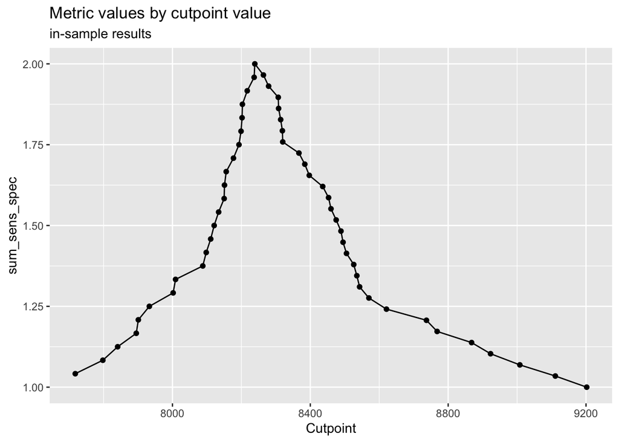

```r
datsecond <- dat %>%
  filter(dnf==0 & olympic=="Tokyo2020" & sex=="Men") %>%
  dplyr::select(rank, time_sec, case_pp, continent, age, gdp2020, prior_attend)

datsecond <- datsecond %>%
  mutate(rank_b = ifelse(as.numeric(rank)<=38, 1, 0))

set.seed(1)
train.rows <- sample(rownames(datsecond), dim(datsecond)[1]*0.7)
test.rows <- setdiff(rownames(datsecond), train.rows)
train_set <- datsecond[train.rows, ]
test_set <- datsecond[test.rows, ]

opt_cut <- cutpointr(train_set, time_sec, rank_b, pos_class = 1, direction = "<=")  #8239
plot_metric(opt_cut)
```

### Optimal Cutpoint for Women

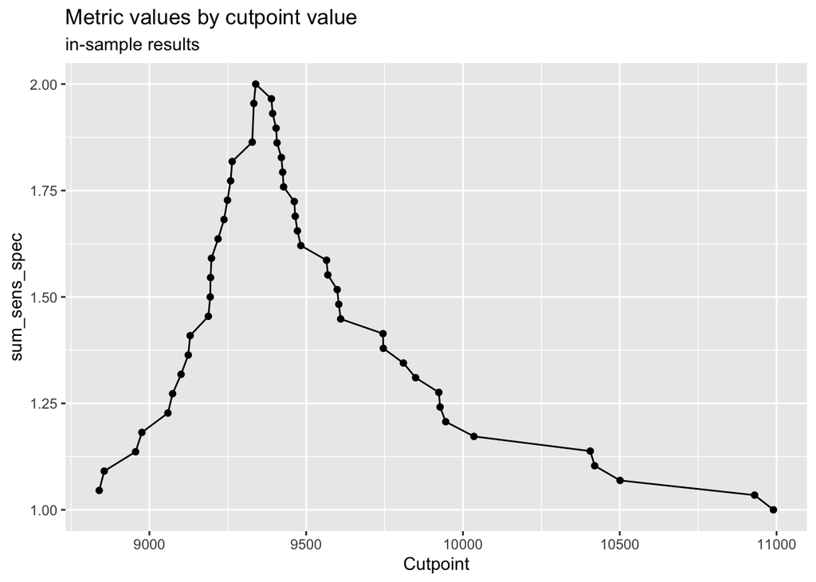

```r
datsecond <- dat %>%
  filter(dnf==0 & olympic=="Tokyo2020" & sex=="Women") %>%
  dplyr::select(rank, time_sec, case_pp, continent, age, gdp2020, prior_attend)

datsecond <- datsecond %>%
  mutate(rank_b = ifelse(as.numeric(rank)<=37, 1, 0))

set.seed(1)
train.rows <- sample(rownames(datsecond), dim(datsecond)[1]*0.7)
test.rows <- setdiff(rownames(datsecond), train.rows)
train_set <- datsecond[train.rows, ]
test_set <- datsecond[test.rows, ]

opt_cut <- cutpointr(train_set, time_sec, rank_b, pos_class = 1, direction = "<=")  # 9339
plot_metric(opt_cut)
```

The above two graphs are plotting the sum of sensitivity and specificity (using the function `sum_sens_spec`) against different cutpoints, and we are choosing the cutpoint that gives us the highest value on the y-axis. From this analysis, the optimal cutpoint for men is 8239, and the optimal cutpoint for women is 9339. We will use these cutpoints throughout our following machine learning and bootstrapping models.

## Bootstrapping

Since the sample size of our dataset is very small, only 71 observations for men and women, respectively, this may cause a problem when training machine learning models. Therefore, we try to apply some methods that incorporate bootstrapping to see whether we can get better results.

We try to compare two sets of original vs. bootstrapped models:

1. Decision tree and random forest
2. Naive Bayes and bootstrapped version of Naive Bayes

We will first fit the models and then present the ROC curves and some statistics at the end to do some comparisons.

## Bootstrapping for Men

```r
# preparing the data
# filter: 2020, Men, finish race
datsecond <- dat %>%
  filter(dnf==0 & olympic=="Tokyo2020" & sex=="Men") %>%
  dplyr::select(time_sec, case_pp, continent, age, gdp2020, prior_attend)

# convert categorical/binary variables into factors
datsecond <- datsecond %>%
  mutate(continent=as.factor(continent), prior_attend=as.factor(prior_attend))

# omit the rows with NA
datsecond<-datsecond %>% filter(!is.na(time_sec))%>% filter(!is.na(case_pp))%>% filter(!is.na(continent))%>% filter(!is.na(age))%>% filter(!is.na(gdp2020))%>% filter(!is.na(prior_attend))

# add the binary outcome variable
cut <- 8239
datsecond<-datsecond%>%
  mutate(timebinary=ifelse(time_sec<cut,0,1)) %>%
  mutate(timebinary=as.factor(timebinary))

# split train (70%), test (30%)
set.seed(1)
x <- stratified(datsecond, "timebinary", 0.70, keep.rownames = TRUE)
train_set <- x %>% dplyr::select(-rn)
train_index <- as.numeric(x$rn)
test_set <- datsecond[-train_index,]
```

### Decision Tree and Random Forest (Men)

```r
# Decision trees
set.seed(1)
tree_fit <- rpart(timebinary ~ case_pp + continent + age + gdp2020 + prior_attend, data = train_set)
p_hat_tree <- predict(tree_fit,newdata=test_set)[,2]
y_hat_tree <- factor(ifelse(p_hat_tree>0.5,1,0))
confusionMatrix(data=as.factor(y_hat_tree),reference=test_set$timebinary,positive="1")
```

```
## Confusion Matrix and Statistics
##
##           Reference
## Prediction 0 1
##          0 5 5
##          1 5 7
##
##                Accuracy : 0.5455
##                  95% CI : (0.3221, 0.7561)
##     No Information Rate : 0.5455
##     P-Value [Acc > NIR] : 0.5869
##
##                   Kappa : 0.0833
##
##  Mcnemar's Test P-Value : 1.0000
##
##             Sensitivity : 0.5833
##             Specificity : 0.5000
##          Pos Pred Value : 0.5833
##          Neg Pred Value : 0.5000
##              Prevalence : 0.5455
##          Detection Rate : 0.3182
##    Detection Prevalence : 0.5455
##       Balanced Accuracy : 0.5417
##
##        'Positive' Class : 1
##
```

```r
# Random Forest
set.seed(1)
rf_fit <- randomForest(timebinary ~ case_pp + continent + age + gdp2020 + prior_attend, data = train_set)
p_hat_rf <- predict(rf_fit,newdata=test_set,type="prob")[,2]
y_hat_rf <- factor(ifelse(p_hat_rf>0.5,1,0))
confusionMatrix(data=as.factor(y_hat_rf),reference=test_set$timebinary,positive="1")
```

```
## Confusion Matrix and Statistics
##
##           Reference
## Prediction 0 1
##          0 4 4
##          1 6 8
##
##                Accuracy : 0.5455
##                  95% CI : (0.3221, 0.7561)
##     No Information Rate : 0.5455
##     P-Value [Acc > NIR] : 0.5869
##
##                   Kappa : 0.0678
##
##  Mcnemar's Test P-Value : 0.7518
##
##             Sensitivity : 0.6667
##             Specificity : 0.4000
##          Pos Pred Value : 0.5714
##          Neg Pred Value : 0.5000
##              Prevalence : 0.5455
##          Detection Rate : 0.3636
##    Detection Prevalence : 0.6364
##       Balanced Accuracy : 0.5333
##
##        'Positive' Class : 1
##
```

```r
# ROC curves
roc_tree <- pROC::roc(test_set$timebinary,p_hat_tree)
roc_rf <- pROC::roc(test_set$timebinary,p_hat_rf)
p1 <- ggroc(list("Decision Tree"=roc_tree, "Random Forest"=roc_rf))+
  theme(legend.title=element_blank())+
  geom_segment(aes(x=1, xend=0,y=0,yend=1),color="black",linetype="dotted")+
  ggtitle("ROC curves - tree (men)") +
  xlab("Specificity")+ylab("Sensitivity")+
  theme(plot.title = element_text(hjust = 0.5))

## AUC
pROC::auc(roc_tree)
```

```
## Area under the curve: 0.5625
```

```r
pROC::auc(roc_rf)
```

```
## Area under the curve: 0.5458
```

### Naive Bayes and the Bootstrapped Version (Men)

```r
# Naive Bayes
nb_fit <- naiveBayes(timebinary ~ case_pp + continent + age + gdp2020 + prior_attend, data = train_set)
p_hat_nb<-predict(nb_fit, newdata=test_set, type="raw")[,2]
y_hat_nb<-factor(ifelse(p_hat_nb>0.5,1,0))
confusionMatrix(data=as.factor(y_hat_nb),reference=test_set$timebinary,positive="1")
```

```
## Confusion Matrix and Statistics
##
##           Reference
## Prediction 0 1
##          0 4 3
##          1 6 9
##
##                Accuracy : 0.5909
##                  95% CI : (0.3635, 0.7929)
##     No Information Rate : 0.5455
##     P-Value [Acc > NIR] : 0.418
##
##                   Kappa : 0.1538
##
##  Mcnemar's Test P-Value : 0.505
##
##             Sensitivity : 0.7500
##             Specificity : 0.4000
##          Pos Pred Value : 0.6000
##          Neg Pred Value : 0.5714
##              Prevalence : 0.5455
##          Detection Rate : 0.4091
##    Detection Prevalence : 0.6818
##       Balanced Accuracy : 0.5750
##
##        'Positive' Class : 1
##
```

```r
# bootstrapped version of naive bayes
rows <- 1:49
pred_class_table <- data.frame(matrix(ncol = nrow(test_set), nrow = 0))

for(iter in 1:100){
  # create the resample train set
  sample_row <- sample(rows, size=85, replace = TRUE)
  resample_train_set <- data.frame()
  for(i in sample_row){
    add_this <- train_set[i,]
    resample_train_set <- rbind(resample_train_set, add_this)
  }
  nb_fit<-naiveBayes(timebinary ~ case_pp + continent + age + gdp2020 + prior_attend, data = resample_train_set)
  p_hat_nb_b<-predict(nb_fit,newdata=test_set,type="raw")[,2]
  y_hat_nb_b<-ifelse(p_hat_nb_b>0.5,1,0)
  pred_class_table <- rbind(pred_class_table, y_hat_nb_b)
}

p_hat_nb_b <- apply(pred_class_table,2,sum)/100
y_hat_nb_b <- factor(ifelse(p_hat_nb_b > 0.5, 1, 0))

confusionMatrix(as.factor(y_hat_nb_b), reference = test_set$timebinary,positive="1")
```

```
## Confusion Matrix and Statistics
##
##           Reference
## Prediction 0 1
##          0 4 4
##          1 6 8
##
##                Accuracy : 0.5455
##                  95% CI : (0.3221, 0.7561)
##     No Information Rate : 0.5455
##     P-Value [Acc > NIR] : 0.5869
##
##                   Kappa : 0.0678
##
##  Mcnemar's Test P-Value : 0.7518
##
##             Sensitivity : 0.6667
##             Specificity : 0.4000
##          Pos Pred Value : 0.5714
##          Neg Pred Value : 0.5000
##              Prevalence : 0.5455
##          Detection Rate : 0.3636
##    Detection Prevalence : 0.6364
##       Balanced Accuracy : 0.5333
##
##        'Positive' Class : 1
##
```

```r
# ROC curves
roc_nb <- pROC::roc(test_set$timebinary,p_hat_nb)
roc_nb_b <- pROC::roc(test_set$timebinary,p_hat_nb_b)
p2 <- ggroc(list("nb"=roc_nb, "nb (bootstrapped)"=roc_nb_b))+
  theme(legend.title=element_blank())+
  geom_segment(aes(x=1, xend=0,y=0,yend=1),color="black",linetype="dotted")+
  ggtitle("ROC curves - Naive Bayes (men)") +
  xlab("Specificity")+ylab("Sensitivity")+
  theme(plot.title = element_text(hjust = 0.5))

## AUC
pROC::auc(roc_nb)
```

```
## Area under the curve: 0.65
```

```r
pROC::auc(roc_nb_b)
```

```
## Area under the curve: 0.6167
```

## Bootstrapping for Women

```r
# preparing the data
# filter: 2020, Women, finish race
datsecond <- dat %>%
  filter(dnf==0 & olympic=="Tokyo2020" & sex=="Women") %>%
  dplyr::select(time_sec, case_pp, continent, age, gdp2020, prior_attend)

# convert categorical/binary variables into factors
datsecond <- datsecond %>%
  mutate(continent=as.factor(continent), prior_attend=as.factor(prior_attend))

# omit the rows with NA
datsecond<-datsecond %>% filter(!is.na(time_sec))%>% filter(!is.na(case_pp))%>% filter(!is.na(continent))%>% filter(!is.na(age))%>% filter(!is.na(gdp2020))%>% filter(!is.na(prior_attend))

# add the binary outcome variable
cut <- 9339
datsecond<-datsecond%>%
  mutate(timebinary=ifelse(time_sec<cut,0,1)) %>%
  mutate(timebinary=as.factor(timebinary))

# split train (70%), test (30%)
set.seed(1)
x <- stratified(datsecond, "timebinary", 0.70, keep.rownames = TRUE)
train_set <- x %>% dplyr::select(-rn)
train_index <- as.numeric(x$rn)
test_set <- datsecond[-train_index,]
```

### Decision Tree and Random Forest (Women)

```r
# Decision trees
set.seed(1)
tree_fit <- rpart(timebinary ~ case_pp + continent + age + gdp2020 + prior_attend, data = train_set)
p_hat_tree <- predict(tree_fit,newdata=test_set)[,2]
y_hat_tree <- factor(ifelse(p_hat_tree>0.5,1,0))
confusionMatrix(data=as.factor(y_hat_tree),reference=test_set$timebinary,positive="1")
```

```
## Confusion Matrix and Statistics
##
##           Reference
## Prediction 0 1
##          0 6 4
##          1 5 7
##
##                Accuracy : 0.5909
##                  95% CI : (0.3635, 0.7929)
##     No Information Rate : 0.5
##     P-Value [Acc > NIR] : 0.2617
##
##                   Kappa : 0.1818
##
##  Mcnemar's Test P-Value : 1.0000
##
##             Sensitivity : 0.6364
##             Specificity : 0.5455
##          Pos Pred Value : 0.5833
##          Neg Pred Value : 0.6000
##              Prevalence : 0.5000
##          Detection Rate : 0.3182
##    Detection Prevalence : 0.5455
##       Balanced Accuracy : 0.5909
##
##        'Positive' Class : 1
##
```

```r
# Random Forest
set.seed(1)
rf_fit <- randomForest(timebinary ~ case_pp + continent + age + gdp2020 + prior_attend, data = train_set)
p_hat_rf <- predict(rf_fit,newdata=test_set,type="prob")[,2]
y_hat_rf <- factor(ifelse(p_hat_rf>0.5,1,0))
confusionMatrix(data=as.factor(y_hat_rf),reference=test_set$timebinary,positive="1")
```

```
## Confusion Matrix and Statistics
##
##           Reference
## Prediction 0 1
##          0 7 5
##          1 4 6
##
##                Accuracy : 0.5909
##                  95% CI : (0.3635, 0.7929)
##     No Information Rate : 0.5
##     P-Value [Acc > NIR] : 0.2617
##
##                   Kappa : 0.1818
##
##  Mcnemar's Test P-Value : 1.0000
##
##             Sensitivity : 0.5455
##             Specificity : 0.6364
##          Pos Pred Value : 0.6000
##          Neg Pred Value : 0.5833
##              Prevalence : 0.5000
##          Detection Rate : 0.2727
##    Detection Prevalence : 0.4545
##       Balanced Accuracy : 0.5909
##
##        'Positive' Class : 1
##
```

```r
# ROC curves
roc_tree <- pROC::roc(test_set$timebinary,p_hat_tree)
roc_rf <- pROC::roc(test_set$timebinary,p_hat_rf)
p3 <- ggroc(list("Decision Tree"=roc_tree, "Random Forest"=roc_rf))+
  theme(legend.title=element_blank())+
  geom_segment(aes(x=1, xend=0,y=0,yend=1),color="black",linetype="dotted")+
  ggtitle("ROC curves - tree (women)") +
  xlab("Specificity")+ylab("Sensitivity")+
  theme(plot.title = element_text(hjust = 0.5))

## AUC
pROC::auc(roc_tree)
```

```
## Area under the curve: 0.5826
```

```r
pROC::auc(roc_rf)
```

```
## Area under the curve: 0.6777
```

### Naive Bayes and the Bootstrapped Version (Women)

```r
# Naive Bayes
nb_fit <- naiveBayes(timebinary ~ case_pp + continent + age + gdp2020 + prior_attend, data = train_set)
p_hat_nb<-predict(nb_fit, newdata=test_set, type="raw")[,2]
y_hat_nb<-factor(ifelse(p_hat_nb>0.5,1,0))
confusionMatrix(data=as.factor(y_hat_nb),reference=test_set$timebinary,positive="1")
```

```
## Confusion Matrix and Statistics
##
##           Reference
## Prediction 0 1
##          0 4 5
##          1 7 6
##
##                Accuracy : 0.4545
##                  95% CI : (0.2439, 0.6779)
##     No Information Rate : 0.5
##     P-Value [Acc > NIR] : 0.7383
##
##                   Kappa : -0.0909
##
##  Mcnemar's Test P-Value : 0.7728
##
##             Sensitivity : 0.5455
##             Specificity : 0.3636
##          Pos Pred Value : 0.4615
##          Neg Pred Value : 0.4444
##              Prevalence : 0.5000
##          Detection Rate : 0.2727
##    Detection Prevalence : 0.5909
##       Balanced Accuracy : 0.4545
##
##        'Positive' Class : 1
##
```

```r
# bootstrapped version of Naive Bayes
rows <- 1:49
pred_class_table <- data.frame(matrix(ncol = nrow(test_set), nrow = 0))

for(iter in 1:100){
  # create the resample train set
  sample_row <- sample(rows, size=85, replace = TRUE)
  resample_train_set <- data.frame()
  for(i in sample_row){
    add_this <- train_set[i,]
    resample_train_set <- rbind(resample_train_set, add_this)
  }
  nb_fit<-naiveBayes(timebinary ~ case_pp + continent + age + gdp2020 + prior_attend, data = resample_train_set)
  p_hat_nb_b<-predict(nb_fit,newdata=test_set,type="raw")[,2]
  y_hat_nb_b<-ifelse(p_hat_nb_b>0.5,1,0)
  pred_class_table <- rbind(pred_class_table, y_hat_nb_b)
}

p_hat_nb_b <- apply(pred_class_table,2,sum)/100
y_hat_nb_b <- factor(ifelse(p_hat_nb_b > 0.5, 1, 0))

confusionMatrix(as.factor(y_hat_nb_b), reference = test_set$timebinary,positive="1")
```

```
## Confusion Matrix and Statistics
##
##           Reference
## Prediction 0 1
##          0 4 5
##          1 7 6
##
##                Accuracy : 0.4545
##                  95% CI : (0.2439, 0.6779)
##     No Information Rate : 0.5
##     P-Value [Acc > NIR] : 0.7383
##
##                   Kappa : -0.0909
##
##  Mcnemar's Test P-Value : 0.7728
##
##             Sensitivity : 0.5455
##             Specificity : 0.3636
##          Pos Pred Value : 0.4615
##          Neg Pred Value : 0.4444
##              Prevalence : 0.5000
##          Detection Rate : 0.2727
##    Detection Prevalence : 0.5909
##       Balanced Accuracy : 0.4545
##
##        'Positive' Class : 1
##
```

```r
# ROC curves
roc_nb <- pROC::roc(test_set$timebinary,p_hat_nb)
roc_nb_b <- pROC::roc(test_set$timebinary,p_hat_nb_b)
p4 <- ggroc(list("nb"=roc_nb, "nb (bootstrapped)"=roc_nb_b))+
  theme(legend.title=element_blank())+
  geom_segment(aes(x=1, xend=0,y=0,yend=1),color="black",linetype="dotted")+
  ggtitle("ROC curves - Naive Bayes (women)") +
  xlab("Specificity")+ylab("Sensitivity")+
  theme(plot.title = element_text(hjust = 0.5))

## AUC
pROC::auc(roc_nb)
```

```
## Area under the curve: 0.5207
```

```r
pROC::auc(roc_nb_b)
```

```
## Area under the curve: 0.4793
```

### ROC Curves

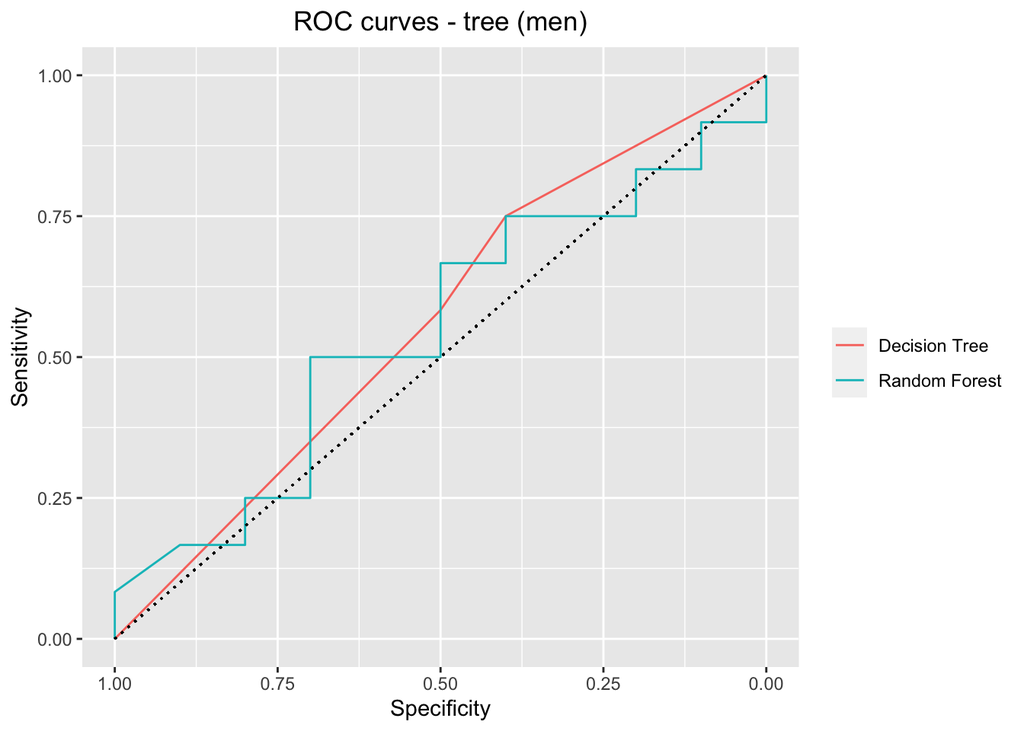

```r
p1
```

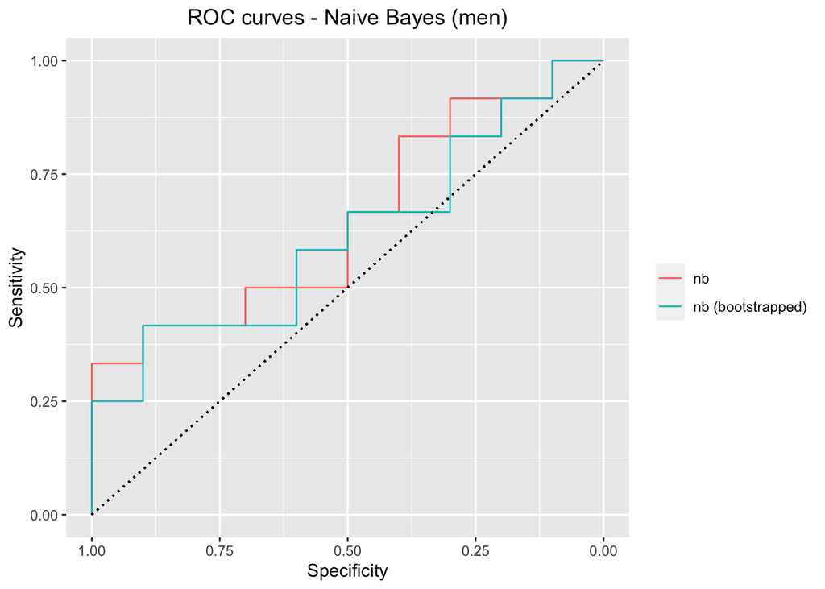

```r
p2
```

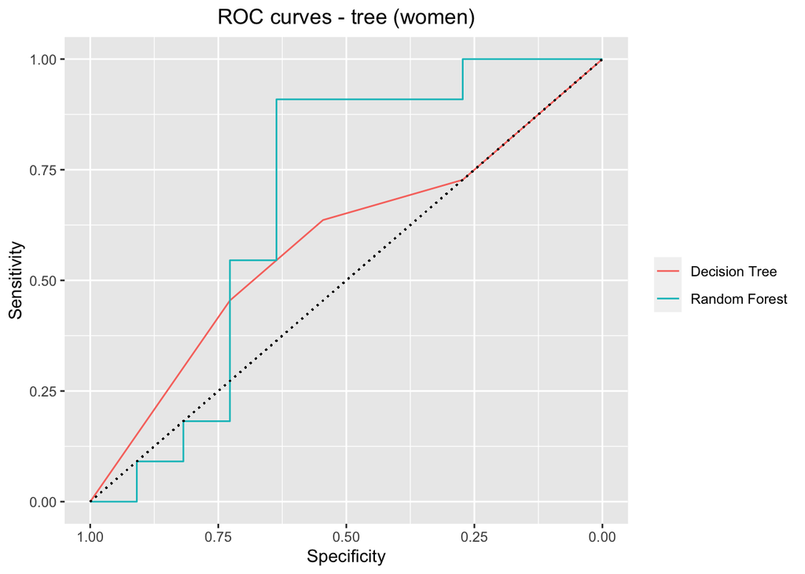

```r
p3
```

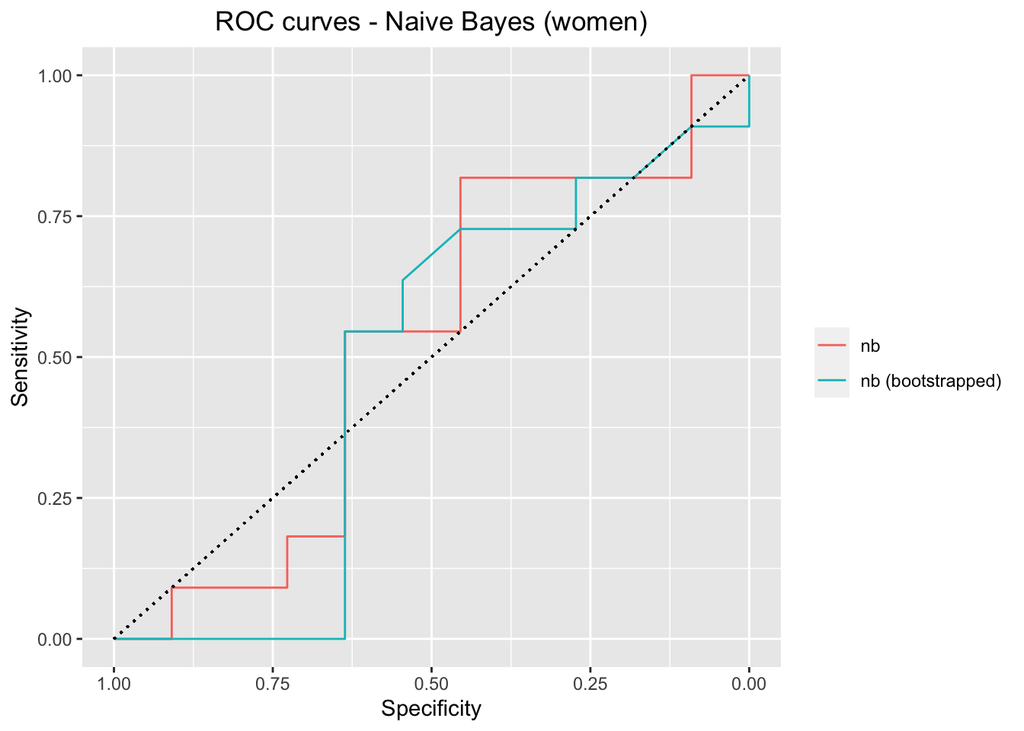

```r
p4
```

### Summary Statistics

```r
# Table for men's models
Men_models <- c("Tree", "Random Forest", "NB", "NB (bootstrapped)")
Accuracy <- c("0.5455", "0.5455", "0.5909", "0.5455")
Sensitivity <- c("0.5833", "0.6667", "0.7500", "0.6667")
Specificity <- c("0.5000", "0.4000", "0.4000", "0.4000")
PPV <- c("0.5833", "0.5714", "0.6000", "0.5714")
NPV <- c("0.5000", "0.5000", "0.5714", "0.5000")
AUC <- c("0.5625", "0.5458", "0.65", "0.6167")

male_df <- data.frame(Men_models, Accuracy, Sensitivity, Specificity, PPV, NPV, AUC)

kable(male_df, format = "markdown", digits = 2)
```

| Men_models | Accuracy | Sensitivity | Specificity | PPV | NPV | AUC |
| --- | --- | --- | --- | --- | --- | --- |
| Tree | 0.5455 | 0.5833 | 0.5000 | 0.5833 | 0.5000 | 0.5625 |
| Random Forest | 0.5455 | 0.6667 | 0.4000 | 0.5714 | 0.5000 | 0.5458 |
| NB | 0.5909 | 0.7500 | 0.4000 | 0.6000 | 0.5714 | 0.65 |
| NB (bootstrapped) | 0.5455 | 0.6667 | 0.4000 | 0.5714 | 0.5000 | 0.6167 |

```r
# Table for men's models
Women_models <- c("Tree", "Random Forest", "NB", "NB (bootstrapped)")
Accuracy <- c("0.5909", "0.5909", "0.4545", "0.4545")
Sensitivity <- c("0.6364", "0.5455", "0.5455", "0.5455")
Specificity <- c("0.5455", "0.6364", "0.3636", "0.3636")
PPV <- c("0.5833", "0.6000", "0.4615", "0.4615")
NPV <- c("0.6000", "0.5833", "0.4444", "0.4444")
AUC <- c("0.5826", "0.6777", "0.5207", "0.4793")

female_df <- data.frame(Women_models, Accuracy, Sensitivity, Specificity, PPV, NPV, AUC)

kable(female_df, format = "markdown", digits = 2)
```

| Women_models | Accuracy | Sensitivity | Specificity | PPV | NPV | AUC |
| --- | --- | --- | --- | --- | --- | --- |
| Tree | 0.5909 | 0.6364 | 0.5455 | 0.5833 | 0.6000 | 0.5826 |
| Random Forest | 0.5909 | 0.5455 | 0.6364 | 0.6000 | 0.5833 | 0.6777 |
| NB | 0.4545 | 0.5455 | 0.3636 | 0.4615 | 0.4444 | 0.5207 |
| NB (bootstrapped) | 0.4545 | 0.5455 | 0.3636 | 0.4615 | 0.4444 | 0.4793 |

### Discussion and Comparison

We can now compare the result of decision tree to random forest, and Naive Bayes to the bootstrapped version of Naive Bayes. If we focus on AUC, we discovered that bootstrapping is only helpful in one of the four comparisons: the women case of tree and random forest. The AUC increases from 0.5826 to 0.6777. For the 3 other cases, bootstrapping either doesn’t have effect on the performance accuracy or is making the result even less accurate.

This result is quite different from our expectation, since we are hoping that bootstrapping can improve the performance of our classification models a bit. Perhaps this is still due to our small sample size problem, and it may be better if we could have a larger dataset.